# Bagging and Random Forest

## From Single Trees to Tree Ensembles

**The Fundamental Problem with Single Trees:**

- **High variance:** Trees are unstable and sensitive to data changes
- **Overfitting:** Deep trees memorize training data rather than learning patterns

**Last time: Pruning helps, but isn’t enough**

- Pruning reduces overfitting, but doesn’t solve the variance problem
- Even optimal trees: small data changes → completely different structure

**Solution: Ensemble Methods**

- Combine predictions from **multiple trees** to reduce variance
- Averaging smooths out individual tree errors, improves performance

**Today’s Methods:**

- **Bagging:** Train many trees and average their predictions
- **Random Forest:** Bagging with randomized feature selection

Q: How do we build **multiple** trees from **one** dataset?

## Bootstrapping

**Basic Idea:** Create many “new” datasets by resampling from your original data

**How it works:**

1. Start with original dataset of \(n\) observations
2. Randomly sample \(n\) observations **with replacement**
3. Some observations appear multiple times, others not at all
4. Repeat to create \(B\) bootstrap samples

**Example:** Original data = {1, 2, 3, 4, 5}

- Bootstrap sample 1: {2, 2, 4, 5, 1}
- Bootstrap sample 2: {3, 5, 5, 4, 3}
- Bootstrap sample 3: {1, 2, 4, 4, 2}

**Key property:** Each bootstrap sample is slightly different, but representative of the original data

**Why useful?** Mimics drawing multiple samples from a population when we only have one dataset!

## The Intuition Behind Ensemble Methods

**Key Insight:** Averaging reduces variance!

If we have \(B\) independent models with variance \(\sigma^2\): \(\text{Var}(\text{Average}) = \frac{\sigma^2}{B}\)

- Similar idea to `k-folds cross validation`
1. **For \(b = 1, 2, \ldots, B\):**
   - Generate bootstrap sample \(Z^{*b}\) from training data
   - Train tree \(T_b\) on \(Z^{*b}\)
2. **For regression:** Average predictions \(\hat{f}_{\text{bag}}(x) = \frac{1}{B} \sum_{b=1}^{B} T_b(x)\)
3. **For classification:** Majority vote \(\hat{C}_{\text{bag}}(x) = \text{majority vote}\{T_1(x), T_2(x), \ldots, T_B(x)\}\)

**Key advantage:** Each tree can be grown deep (low bias), but averaging reduces variance

## Bagging in Practice: Boston Housing

- Predicts median home value (`medv`) in Boston suburbs
- 506 observations, 13 predictor variables (crime rate, rooms, age, etc.)

```r
# Create training dataset
train_idx <- sample(nrow(Boston), nrow(Boston)/2)
boston_train <- Boston[train_idx, ]
boston_test <- Boston[-train_idx, ]

# Single regression tree for comparison (using rpart from previous days)
single_tree <- rpart(medv ~ ., data = boston_train)
single_pred <- predict(single_tree, boston_test)
single_mse <- mean((single_pred - boston_test$medv)^2)

# Bagging with randomForest (mtry = p means all variables considered)
bag_boston <- randomForest(medv ~ ., data = boston_train,
                           mtry = ncol(boston_train) - 1,
                           ntree = 500, importance = TRUE)

# Bagging predictions
bag_pred <- predict(bag_boston, boston_test)
bag_mse <- mean((bag_pred - boston_test$medv)^2)
```

```
## Single tree MSE: 24.67  | Bagging MSE: 14.82  | Improvement: 39.9 %
```

## Visualizing Bagging Performance

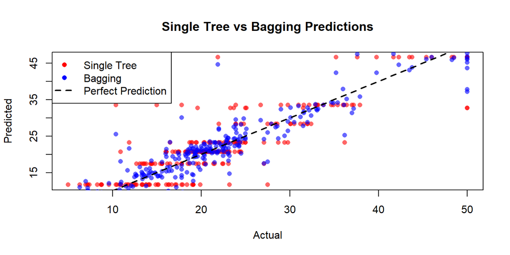

- Single tree will have the same prediction for multiple values
- Red points (single tree) show more scatter from the diagonal
- Blue points (bagging) cluster closer to perfect prediction line
- Bagging reduces extreme prediction errors

## Out-of-Bag (OOB) Error Estimation

**Key Insight:** Bootstrap samples don’t include all observations!

- Each bootstrap sample includes ~63.2% of original observations
- Remaining ~36.8% are “out-of-bag” (OOB)
- Use OOB observations as **validation** set for each tree

**OOB Error Calculation:**

1. For each observation, average predictions from trees where it was OOB
2. Calculate error between OOB predictions and true values
3. No need for separate validation set!

```r
# OOB error from bagging model
oob_mse <- tail(bag_boston$mse, 1)  # Final OOB MSE
cat("OOB MSE:", round(oob_mse, 2),
    " | Test MSE:", round(bag_mse, 2))
```

```
## OOB MSE: 13.56  | Test MSE: 14.82
```

## Visualizing OOB Error Convergence

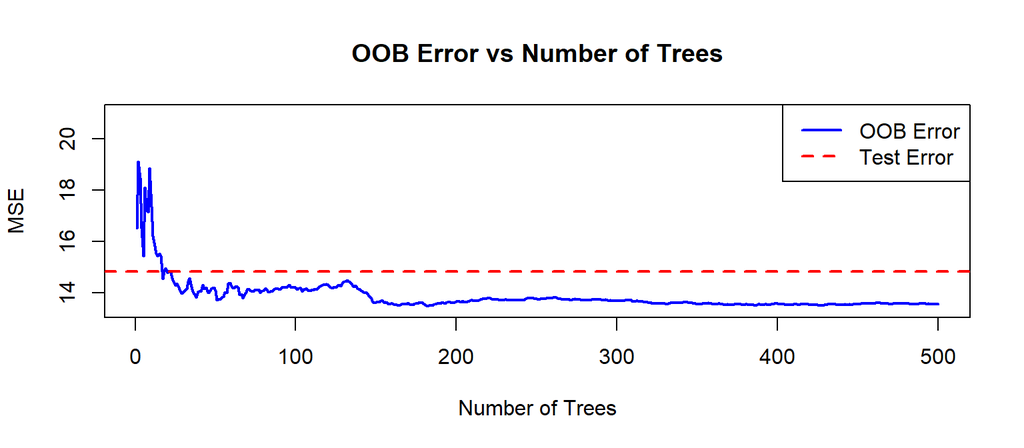

- Early on: few trees, high variance in predictions
- As trees accumulate: averaging smooths out errors
- After ~100-150 trees: performance plateaus (enough trees to stabilize)
- Adding more trees doesn’t hurt (no overfitting!)
- OOB error is similar to test error (validation)

## Random Forests: Decorrelating Trees

**Problem with Bagging:** Trees are often similar (correlated)

- If one predictor is very strong, most trees will use it first
- Averaging correlated predictions doesn’t reduce variance much

**Random Forest Solution:**

- At each split, randomly sample \(m\) predictors from all \(p\) predictors
- Choose best split among the \(m\) predictors only
- Decorrelates trees → better variance reduction

**Typical choices for \(m\):**

- **Regression:** \(m = p/3\)
- **Classification:** \(m = \sqrt{p}\)

## Random Forest Implementation

```r
# Random Forest with default mtry (p/3 for regression)
rf_boston <- randomForest(medv ~ ., data = boston_train,
                         mtry = (ncol(boston_train) - 1) / 3,  # Default for regression
                         ntree = 500, importance = TRUE)

# Random Forest predictions
rf_pred <- predict(rf_boston, boston_test)
rf_mse <- mean((rf_pred - boston_test$medv)^2)
```

```
##          Method Test_MSE R_squared mtry
## 1   Single Tree    24.67     0.720    1
## 2       Bagging    14.82     0.832   13
## 3 Random Forest    12.68     0.856    4
```

```
##
## Random Forest improves upon bagging: 14.5 % reduction in MSE
```

## Variable Importance in Random Forests

**%IncMSE (Percent Increase in MSE):**

- Measures how much prediction error increases when a variable is randomly permuted
- Higher values = more important for accurate predictions
- **How it works:** Shuffle variable values → breaks its relationship with outcome → worse predictions
- Most reliable metric for understanding predictive power

**Key Boston Housing Variables:**

- `lstat`: % of population with lower socioeconomic status
- `rm`: Average number of rooms per dwelling
- `dis`: Weighted distances to employment centers
- `crim`: Per capita crime rate
- `nox`: Nitrogen oxide concentration (air pollution)

## Visualizing variable importance

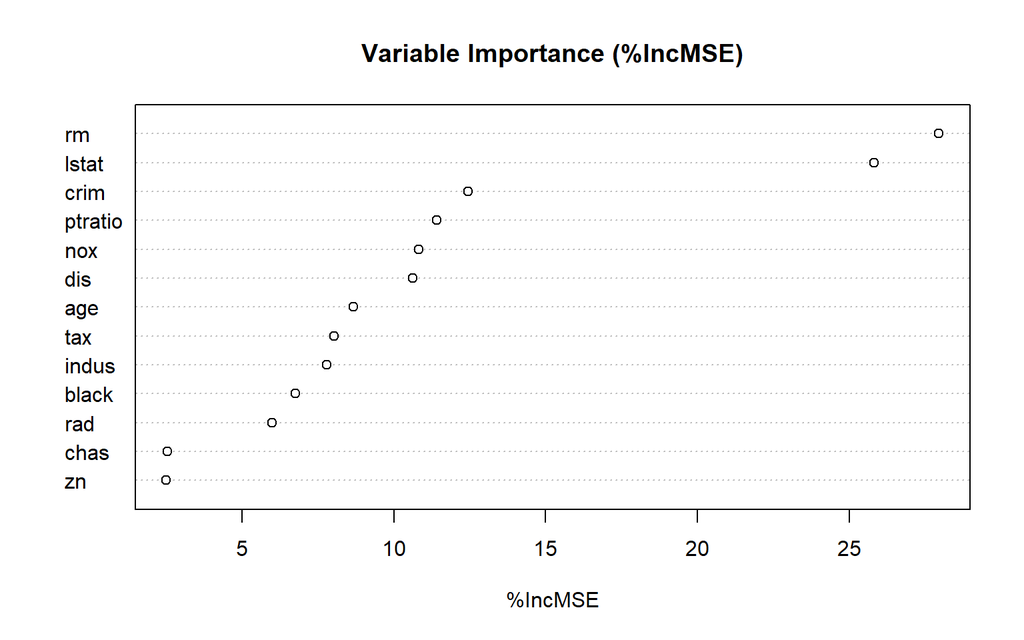

```r
# Create importance plot focusing on %IncMSE
varImpPlot(rf_boston, type = 1, main = "Variable Importance (%IncMSE)")
```

## Extracting Variable Importance

- We can also save down the importance scores to a variable

```r
# Extract variable importance from Random Forest model
importance_data <- importance(rf_boston)

# Sort by %IncMSE in descending order and display
importance_sorted <- sort(importance_data[, "%IncMSE"], decreasing = TRUE)
print(round(importance_sorted, 2))
```

```
##      rm   lstat    crim ptratio     nox     dis     age     tax   indus   black
##   27.96   25.83   12.45   11.41   10.81   10.63    8.67    8.03    7.80    6.75
##     rad    chas      zn
##    5.99    2.53    2.50
```

- `rm` and `lstat` are most important predictors
- Room count and lower status % strongly predict home values
- Other factors (distance, crime, pollution) also matter but less so

## Tuning Random Forest Parameters

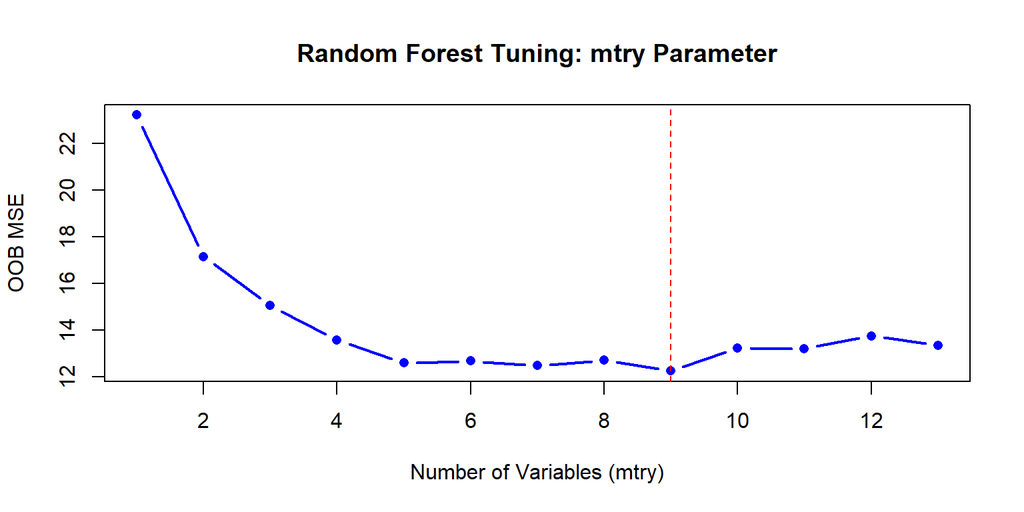

```
## Optimal mtry: 9
```

```
## Default mtry (p/3): 4
```

## Partial Dependence Plots

- One criticism of Random Forest is that it is not very interpretable (can’t see underlying trees)
- One tool we can use is **Partial Dependence Plots**
  - Show the **marginal effect** of a variable on the predicted outcome
  - Answer: “How does the prediction change as this variable changes, holding all else constant?”
  - Calculated by: averaging predictions across many values of the target variable

**How they work:**

1. Pick a variable (e.g., `lstat`) and a range of values for it
2. For each value, set ALL observations to that value
3. Get predictions for all observations (leaving all other variables), then average
4. Plot: variable value (x-axis) vs average prediction (y-axis)

**Why useful?**

- Reveals relationships learned by the model (linear, non-linear, threshold effects)
- Helps interpret “black box” Random Forest models

## Partial Dependence: Top Predictors

```r
partial_dep <- function(rf_model, data, var_name, grid_points = 20) {
  var_range <- range(data[[var_name]], na.rm = TRUE)
  grid <- seq(var_range[1], var_range[2], length.out = grid_points)
  predictions <- numeric(length(grid))
  for(i in seq_along(grid)) {
    temp_data <- data
    temp_data[[var_name]] <- grid[i]
    predictions[i] <- mean(predict(rf_model, temp_data))
  }
  data.frame(x = grid, y = predictions)
}
```

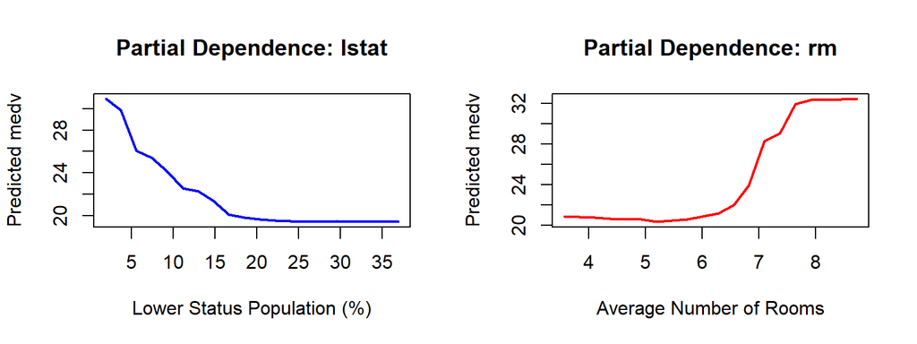

## Advantages and Disadvantages

**Random Forest Advantages:**

- **High accuracy:** Often best off-the-shelf method
- **More reisistance to overfitting** Adding trees helps then plateaus
- **Variable importance:** Identifies which predictors matter most
- **OOB error:** No need for separate validation set
- **Parallel training:** Trees can be built independently

**Random Forest Disadvantages:**

- **Less interpretable:** Can’t easily extract decision rules
- **Can still overfit training data:** Deep trees may memorize patterns
  - can try tuning with `mtry`, `nodesize`, or `maxnodes`
- **Still struggles with linear relationships:** Many splits needed for simple linear patterns

**When to use Random Forests:**

- High-dimensional data with complex interactions
- Need variable importance rankings
- Want robust, accurate predictions without much tuning

## Random Forest for Classification: Credit Default

```r
# Load and prepare Default data from ISLR2
data(Default)
Default <- na.omit(Default)

# Train/test split
set.seed(1)
train_idx <- sample(nrow(Default), 0.7 * nrow(Default))
default_train <- Default[train_idx, ]
default_test <- Default[-train_idx, ]

# Random Forest for classification
rf_default <- randomForest(default ~ ., data = default_train,
                        mtry = sqrt(ncol(default_train) - 1),  # Default for classification
                        ntree = 500, importance = TRUE)

# Predictions and confusion matrix
rf_pred_class <- predict(rf_default, default_test)
conf_matrix <- table(Predicted = rf_pred_class, Actual = default_test$default)

# Calculate metrics
accuracy <- sum(diag(conf_matrix)) / sum(conf_matrix)
sensitivity <- conf_matrix[2,2] / sum(conf_matrix[,2])
specificity <- conf_matrix[1,1] / sum(conf_matrix[,1])
```

## Comparing Single Trees vs Ensembles

```
##          Method Accuracy Precision Recall F1_Score
## 1   Single Tree    0.973     0.756  0.304    0.434
## 2       Bagging    0.969     0.622  0.225    0.331
## 3 Random Forest    0.969     0.632  0.235    0.343
```

**Key Observations:**

- **Single tree outperforms both ensemble methods** across ALL metrics
- **Why do ensembles fail here?**
  - Only 3 predictors - Random Forests need more features to shine
  - Strong linear relationship (balance predicts default well)
  - Extreme class imbalance (~97% non-default)
  - Small dataset - ensembles benefit from larger, more complex data
  - Simple decision boundary may not need ensemble averaging
- **Important lesson:** More complex ≠ better performance
- **When ensembles help:** Many predictors, complex interactions, non-linear patterns
- **This example shows:** Always compare methods - don’t assume RF always wins!

## Summary and Next Steps

**The Journey Ahead:**

- **Day 18:** Boosting - Building trees sequentially to reduce bias